# HAR[Using SP data]

## Problem Statement :

**Human activity recognition is the problem of classifying sequences of accelerometer data recorded by specialized harnesses or smart phones into known well-defined movements.**

It is a challenging problem given the large number of observations produced each second, the temporal nature of the observations, and the lack of a clear way to relate accelerometer data to known movements.</strong>

## Data Collection:

**The experiments have been carried out with a group of 30 volunteers within an age bracket of 19-48 years. Each person performed six activities (WALKING, WALKING_UPSTAIRS, WALKING_DOWNSTAIRS, SITTING, STANDING, LAYING) wearing a smartphone (Samsung Galaxy S II) on the waist. Using its embedded accelerometer and gyroscope, we captured 3-axial linear acceleration and 3-axial angular velocity at a constant rate of 50Hz. The experiments have been video-recorded to label the data manually. The obtained dataset has been randomly partitioned into two sets, where 70% of the volunteers was selected for generating the training data and 30% the test data. The sensor signals (accelerometer and gyroscope) were pre-processed by applying noise filters and then sampled in fixed-width sliding windows of 2.56 sec and 50% overlap (128 readings/window). The sensor acceleration signal, which has gravitational and body motion components, was separated using a Butterworth low-pass filter into body acceleration and gravity. The gravitational force is assumed to have only low frequency components, therefore a filter with 0.3 Hz cutoff frequency was used. From each window, a vector of features was obtained by calculating variables from the time and frequency domain.**

```python
#import required libraries:
import pandas as pd
import numpy as np
import matplotlib.pyplot as plt
import seaborn as sns
%matplotlib inline
```

```python
#reading the data:
train=pd.read_csv("train.csv")
test=pd.read_csv("test.csv")
print(train.shape)
print(test.shape)
print(type(train),type(test))
```

```
(7352, 563)
(2947, 563)
<class 'pandas.core.frame.DataFrame'> <class 'pandas.core.frame.DataFrame'>
```

```python
#displaying the features:
#not gonna display the head as the the values are too large
pd.options.display.max_seq_items=600 #to display all the items in the list
train.columns #to display columns
```

```
Index(['tBodyAcc-mean()-X', 'tBodyAcc-mean()-Y', 'tBodyAcc-mean()-Z',
       'tBodyAcc-std()-X', 'tBodyAcc-std()-Y', 'tBodyAcc-std()-Z',
       'tBodyAcc-mad()-X', 'tBodyAcc-mad()-Y', 'tBodyAcc-mad()-Z',
       'tBodyAcc-max()-X', 'tBodyAcc-max()-Y', 'tBodyAcc-max()-Z',
       'tBodyAcc-min()-X', 'tBodyAcc-min()-Y', 'tBodyAcc-min()-Z',
       'tBodyAcc-sma()', 'tBodyAcc-energy()-X', 'tBodyAcc-energy()-Y',
       'tBodyAcc-energy()-Z', 'tBodyAcc-iqr()-X', 'tBodyAcc-iqr()-Y',
       'tBodyAcc-iqr()-Z', 'tBodyAcc-entropy()-X', 'tBodyAcc-entropy()-Y',
       'tBodyAcc-entropy()-Z', 'tBodyAcc-arCoeff()-X,1',
       'tBodyAcc-arCoeff()-X,2', 'tBodyAcc-arCoeff()-X,3',
       'tBodyAcc-arCoeff()-X,4', 'tBodyAcc-arCoeff()-Y,1',
       'tBodyAcc-arCoeff()-Y,2', 'tBodyAcc-arCoeff()-Y,3',
       'tBodyAcc-arCoeff()-Y,4', 'tBodyAcc-arCoeff()-Z,1',
       'tBodyAcc-arCoeff()-Z,2', 'tBodyAcc-arCoeff()-Z,3',
       'tBodyAcc-arCoeff()-Z,4', 'tBodyAcc-correlation()-X,Y',
       'tBodyAcc-correlation()-X,Z', 'tBodyAcc-correlation()-Y,Z',
       'tGravityAcc-mean()-X', 'tGravityAcc-mean()-Y', 'tGravityAcc-mean()-Z',
       'tGravityAcc-std()-X', 'tGravityAcc-std()-Y', 'tGravityAcc-std()-Z',
       'tGravityAcc-mad()-X', 'tGravityAcc-mad()-Y', 'tGravityAcc-mad()-Z',
       'tGravityAcc-max()-X', 'tGravityAcc-max()-Y', 'tGravityAcc-max()-Z',
       'tGravityAcc-min()-X', 'tGravityAcc-min()-Y', 'tGravityAcc-min()-Z',
       'tGravityAcc-sma()', 'tGravityAcc-energy()-X', 'tGravityAcc-energy()-Y',
       'tGravityAcc-energy()-Z', 'tGravityAcc-iqr()-X', 'tGravityAcc-iqr()-Y',
       'tGravityAcc-iqr()-Z', 'tGravityAcc-entropy()-X',
       'tGravityAcc-entropy()-Y', 'tGravityAcc-entropy()-Z',
       'tGravityAcc-arCoeff()-X,1', 'tGravityAcc-arCoeff()-X,2',
       'tGravityAcc-arCoeff()-X,3', 'tGravityAcc-arCoeff()-X,4',
       'tGravityAcc-arCoeff()-Y,1', 'tGravityAcc-arCoeff()-Y,2',
       'tGravityAcc-arCoeff()-Y,3', 'tGravityAcc-arCoeff()-Y,4',
       'tGravityAcc-arCoeff()-Z,1', 'tGravityAcc-arCoeff()-Z,2',
       'tGravityAcc-arCoeff()-Z,3', 'tGravityAcc-arCoeff()-Z,4',
       'tGravityAcc-correlation()-X,Y', 'tGravityAcc-correlation()-X,Z',
       'tGravityAcc-correlation()-Y,Z', 'tBodyAccJerk-mean()-X',
       'tBodyAccJerk-mean()-Y', 'tBodyAccJerk-mean()-Z',
       'tBodyAccJerk-std()-X', 'tBodyAccJerk-std()-Y', 'tBodyAccJerk-std()-Z',
       'tBodyAccJerk-mad()-X', 'tBodyAccJerk-mad()-Y', 'tBodyAccJerk-mad()-Z',
       'tBodyAccJerk-max()-X', 'tBodyAccJerk-max()-Y', 'tBodyAccJerk-max()-Z',
       'tBodyAccJerk-min()-X', 'tBodyAccJerk-min()-Y', 'tBodyAccJerk-min()-Z',
       'tBodyAccJerk-sma()', 'tBodyAccJerk-energy()-X',
       'tBodyAccJerk-energy()-Y', 'tBodyAccJerk-energy()-Z',
```

[output cut: 208 more lines]

```
       'fBodyBodyGyroMag-iqr()', 'fBodyBodyGyroMag-entropy()',
       'fBodyBodyGyroMag-maxInds', 'fBodyBodyGyroMag-meanFreq()',
       'fBodyBodyGyroMag-skewness()', 'fBodyBodyGyroMag-kurtosis()',
       'fBodyBodyGyroJerkMag-mean()', 'fBodyBodyGyroJerkMag-std()',
       'fBodyBodyGyroJerkMag-mad()', 'fBodyBodyGyroJerkMag-max()',
       'fBodyBodyGyroJerkMag-min()', 'fBodyBodyGyroJerkMag-sma()',
       'fBodyBodyGyroJerkMag-energy()', 'fBodyBodyGyroJerkMag-iqr()',
       'fBodyBodyGyroJerkMag-entropy()', 'fBodyBodyGyroJerkMag-maxInds',
       'fBodyBodyGyroJerkMag-meanFreq()', 'fBodyBodyGyroJerkMag-skewness()',
       'fBodyBodyGyroJerkMag-kurtosis()', 'angle(tBodyAccMean,gravity)',
       'angle(tBodyAccJerkMean),gravityMean)',
       'angle(tBodyGyroMean,gravityMean)',
       'angle(tBodyGyroJerkMean,gravityMean)', 'angle(X,gravityMean)',
       'angle(Y,gravityMean)', 'angle(Z,gravityMean)', 'subject', 'Activity'],
      dtype='object')
```

```python
#checking for NULL values:
pd.options.display.max_rows=600
train.isnull().sum()
#there are no NULL values in the data
```

```
tBodyAcc-mean()-X                       0
tBodyAcc-mean()-Y                       0
tBodyAcc-mean()-Z                       0
tBodyAcc-std()-X                        0
tBodyAcc-std()-Y                        0
tBodyAcc-std()-Z                        0
tBodyAcc-mad()-X                        0
tBodyAcc-mad()-Y                        0
tBodyAcc-mad()-Z                        0
tBodyAcc-max()-X                        0
tBodyAcc-max()-Y                        0
tBodyAcc-max()-Z                        0
tBodyAcc-min()-X                        0
tBodyAcc-min()-Y                        0
tBodyAcc-min()-Z                        0
tBodyAcc-sma()                          0
tBodyAcc-energy()-X                     0
tBodyAcc-energy()-Y                     0
tBodyAcc-energy()-Z                     0
tBodyAcc-iqr()-X                        0
tBodyAcc-iqr()-Y                        0
tBodyAcc-iqr()-Z                        0
tBodyAcc-entropy()-X                    0
tBodyAcc-entropy()-Y                    0
tBodyAcc-entropy()-Z                    0
tBodyAcc-arCoeff()-X,1                  0
tBodyAcc-arCoeff()-X,2                  0
tBodyAcc-arCoeff()-X,3                  0
tBodyAcc-arCoeff()-X,4                  0
tBodyAcc-arCoeff()-Y,1                  0
tBodyAcc-arCoeff()-Y,2                  0
tBodyAcc-arCoeff()-Y,3                  0
tBodyAcc-arCoeff()-Y,4                  0
tBodyAcc-arCoeff()-Z,1                  0
tBodyAcc-arCoeff()-Z,2                  0
tBodyAcc-arCoeff()-Z,3                  0
tBodyAcc-arCoeff()-Z,4                  0
tBodyAcc-correlation()-X,Y              0
tBodyAcc-correlation()-X,Z              0
tBodyAcc-correlation()-Y,Z              0
```

[output cut: 509 more lines]

```
fBodyBodyGyroJerkMag-entropy()          0
fBodyBodyGyroJerkMag-maxInds            0
fBodyBodyGyroJerkMag-meanFreq()         0
fBodyBodyGyroJerkMag-skewness()         0
fBodyBodyGyroJerkMag-kurtosis()         0
angle(tBodyAccMean,gravity)             0
angle(tBodyAccJerkMean),gravityMean)    0
angle(tBodyGyroMean,gravityMean)        0
angle(tBodyGyroJerkMean,gravityMean)    0
angle(X,gravityMean)                    0
angle(Y,gravityMean)                    0
angle(Z,gravityMean)                    0
subject                                 0
Activity                                0
dtype: int64
```

```python
train.describe()
```

|  | tBodyAcc-mean()-X | tBodyAcc-mean()-Y | tBodyAcc-mean()-Z | tBodyAcc-std()-X | tBodyAcc-std()-Y | tBodyAcc-std()-Z | tBodyAcc-mad()-X | tBodyAcc-mad()-Y | tBodyAcc-mad()-Z | tBodyAcc-max()-X | ... | fBodyBodyGyroJerkMag-skewness() | fBodyBodyGyroJerkMag-kurtosis() | angle(tBodyAccMean,gravity) | angle(tBodyAccJerkMean),gravityMean) | angle(tBodyGyroMean,gravityMean) | angle(tBodyGyroJerkMean,gravityMean) | angle(X,gravityMean) | angle(Y,gravityMean) | angle(Z,gravityMean) | subject |
| --- | --- | --- | --- | --- | --- | --- | --- | --- | --- | --- | --- | --- | --- | --- | --- | --- | --- | --- | --- | --- | --- |
| count | 7352.000000 | 7352.000000 | 7352.000000 | 7352.000000 | 7352.000000 | 7352.000000 | 7352.000000 | 7352.000000 | 7352.000000 | 7352.000000 | ... | 7352.000000 | 7352.000000 | 7352.000000 | 7352.000000 | 7352.000000 | 7352.000000 | 7352.000000 | 7352.000000 | 7352.000000 | 7352.000000 |
| mean | 0.274488 | -0.017695 | -0.109141 | -0.605438 | -0.510938 | -0.604754 | -0.630512 | -0.526907 | -0.606150 | -0.468604 | ... | -0.307009 | -0.625294 | 0.008684 | 0.002186 | 0.008726 | -0.005981 | -0.489547 | 0.058593 | -0.056515 | 17.413085 |
| std | 0.070261 | 0.040811 | 0.056635 | 0.448734 | 0.502645 | 0.418687 | 0.424073 | 0.485942 | 0.414122 | 0.544547 | ... | 0.321011 | 0.307584 | 0.336787 | 0.448306 | 0.608303 | 0.477975 | 0.511807 | 0.297480 | 0.279122 | 8.975143 |
| min | -1.000000 | -1.000000 | -1.000000 | -1.000000 | -0.999873 | -1.000000 | -1.000000 | -1.000000 | -1.000000 | -1.000000 | ... | -0.995357 | -0.999765 | -0.976580 | -1.000000 | -1.000000 | -1.000000 | -1.000000 | -1.000000 | -1.000000 | 1.000000 |
| 25% | 0.262975 | -0.024863 | -0.120993 | -0.992754 | -0.978129 | -0.980233 | -0.993591 | -0.978162 | -0.980251 | -0.936219 | ... | -0.542602 | -0.845573 | -0.121527 | -0.289549 | -0.482273 | -0.376341 | -0.812065 | -0.017885 | -0.143414 | 8.000000 |
| 50% | 0.277193 | -0.017219 | -0.108676 | -0.946196 | -0.851897 | -0.859365 | -0.950709 | -0.857328 | -0.857143 | -0.881637 | ... | -0.343685 | -0.711692 | 0.009509 | 0.008943 | 0.008735 | -0.000368 | -0.709417 | 0.182071 | 0.003181 | 19.000000 |
| 75% | 0.288461 | -0.010783 | -0.097794 | -0.242813 | -0.034231 | -0.262415 | -0.292680 | -0.066701 | -0.265671 | -0.017129 | ... | -0.126979 | -0.503878 | 0.150865 | 0.292861 | 0.506187 | 0.359368 | -0.509079 | 0.248353 | 0.107659 | 26.000000 |
| max | 1.000000 | 1.000000 | 1.000000 | 1.000000 | 0.916238 | 1.000000 | 1.000000 | 0.967664 | 1.000000 | 1.000000 | ... | 0.989538 | 0.956845 | 1.000000 | 1.000000 | 0.998702 | 0.996078 | 1.000000 | 0.478157 | 1.000000 | 30.000000 |

8 rows × 562 columns

Here we can observe that the train data is scaled using MinMaxScaler

```python
test.describe()
```

|  | tBodyAcc-mean()-X | tBodyAcc-mean()-Y | tBodyAcc-mean()-Z | tBodyAcc-std()-X | tBodyAcc-std()-Y | tBodyAcc-std()-Z | tBodyAcc-mad()-X | tBodyAcc-mad()-Y | tBodyAcc-mad()-Z | tBodyAcc-max()-X | ... | fBodyBodyGyroJerkMag-skewness() | fBodyBodyGyroJerkMag-kurtosis() | angle(tBodyAccMean,gravity) | angle(tBodyAccJerkMean),gravityMean) | angle(tBodyGyroMean,gravityMean) | angle(tBodyGyroJerkMean,gravityMean) | angle(X,gravityMean) | angle(Y,gravityMean) | angle(Z,gravityMean) | subject |
| --- | --- | --- | --- | --- | --- | --- | --- | --- | --- | --- | --- | --- | --- | --- | --- | --- | --- | --- | --- | --- | --- |
| count | 2947.000000 | 2947.000000 | 2947.000000 | 2947.000000 | 2947.000000 | 2947.000000 | 2947.000000 | 2947.000000 | 2947.000000 | 2947.000000 | ... | 2947.000000 | 2947.000000 | 2947.000000 | 2947.000000 | 2947.000000 | 2947.000000 | 2947.000000 | 2947.000000 | 2947.000000 | 2947.000000 |
| mean | 0.273996 | -0.017863 | -0.108386 | -0.613635 | -0.508330 | -0.633797 | -0.641278 | -0.522676 | -0.637038 | -0.462063 | ... | -0.277593 | -0.598756 | 0.005264 | 0.003799 | 0.040029 | -0.017298 | -0.513923 | 0.074886 | -0.048720 | 12.986427 |
| std | 0.060570 | 0.025745 | 0.042747 | 0.412597 | 0.494269 | 0.362699 | 0.385199 | 0.479899 | 0.357753 | 0.523916 | ... | 0.317245 | 0.311042 | 0.336147 | 0.445077 | 0.634989 | 0.501311 | 0.509205 | 0.324300 | 0.241467 | 6.950984 |
| min | -0.592004 | -0.362884 | -0.576184 | -0.999606 | -1.000000 | -0.998955 | -0.999417 | -0.999914 | -0.998899 | -0.952357 | ... | -1.000000 | -1.000000 | -1.000000 | -0.993402 | -0.998898 | -0.991096 | -0.984195 | -0.913704 | -0.949228 | 2.000000 |
| 25% | 0.262075 | -0.024961 | -0.121162 | -0.990914 | -0.973664 | -0.976122 | -0.992333 | -0.974131 | -0.975352 | -0.934447 | ... | -0.517494 | -0.829593 | -0.130541 | -0.282600 | -0.518924 | -0.428375 | -0.829722 | 0.022140 | -0.098485 | 9.000000 |
| 50% | 0.277113 | -0.016967 | -0.108458 | -0.931214 | -0.790972 | -0.827534 | -0.937664 | -0.799907 | -0.817005 | -0.852659 | ... | -0.311023 | -0.683672 | 0.005188 | 0.006767 | 0.047113 | -0.026726 | -0.729648 | 0.181563 | -0.010671 | 12.000000 |
| 75% | 0.288097 | -0.010143 | -0.097123 | -0.267395 | -0.105919 | -0.311432 | -0.321719 | -0.133488 | -0.322771 | -0.009965 | ... | -0.083559 | -0.458332 | 0.146200 | 0.288113 | 0.622151 | 0.394387 | -0.545939 | 0.260252 | 0.092373 | 18.000000 |
| max | 0.671887 | 0.246106 | 0.494114 | 0.465299 | 1.000000 | 0.489703 | 0.439657 | 1.000000 | 0.427958 | 0.786436 | ... | 1.000000 | 1.000000 | 0.998898 | 0.986347 | 1.000000 | 1.000000 | 0.833180 | 1.000000 | 0.973113 | 24.000000 |

8 rows × 562 columns

## Details of FEATURES in the data:

These signals were used to estimate variables of the feature vector for each pattern:  
'-XYZ' is used to denote 3-axial signals in the X, Y and Z directions.  
tBodyAcc-XYZ  
tGravityAcc-XYZ  
tBodyAccJerk-XYZ  
tBodyGyro-XYZ  
tBodyGyroJerk-XYZ  
tBodyAccMag  
tGravityAccMag  
tBodyAccJerkMag  
tBodyGyroMag  
tBodyGyroJerkMag  
fBodyAcc-XYZ  
fBodyAccJerk-XYZ  
fBodyGyro-XYZ  
fBodyAccMag  
fBodyAccJerkMag  
fBodyGyroMag  
fBodyGyroJerkMag

# Feature Engineering:

The set of variables that were estimated from these signals are:  
mean(): Mean value  
std(): Standard deviation  
mad(): Median absolute deviation  
max(): Largest value in array  
min(): Smallest value in array  
sma(): Signal magnitude area  
energy(): Energy measure. Sum of the squares divided by the number of values.  
iqr(): Interquartile range  
entropy(): Signal entropy  
arCoeff(): Autorregresion coefficients with Burg order equal to 4  
correlation(): correlation coefficient between two signals  
maxInds(): index of the frequency component with largest magnitude  
meanFreq(): Weighted average of the frequency components to obtain a mean frequency  
skewness(): skewness of the frequency domain signal  
kurtosis(): kurtosis of the frequency domain signal  
bandsEnergy(): Energy of a frequency interval within the 64 bins of the FFT of each window.  
angle(): Angle between to vectors.  
Additional vectors obtained by averaging the signals in a signal window sample. These are used on the angle() variable:  
gravityMean  
tBodyAccMean  
tBodyAccJerkMean  
tBodyGyroMean  
tBodyGyroJerkMean  
OUTPUT COLUMN--> Here the output column is the ACTIVITY column.

### Models that can be used to make predictions on this data:

- ML models:
  - Logistic Regression
  - KNN
  - Naive Bayes
  - Decision Trees
  - Random Forest
- DL models:
  - RNNs
  - CNNs

# Data Visualizations:

#### Visualizing the class imbalance in the Output Columns

This helps us to present how accurately the classification can be done, as , any high imblances in the data might lead to mispredictions

```python
train.Activity.unique()
#we can see there are only 6 classes we need to classify the data into
```

```
array(['STANDING', 'SITTING', 'LAYING', 'WALKING', 'WALKING_DOWNSTAIRS',
       'WALKING_UPSTAIRS'], dtype=object)
```

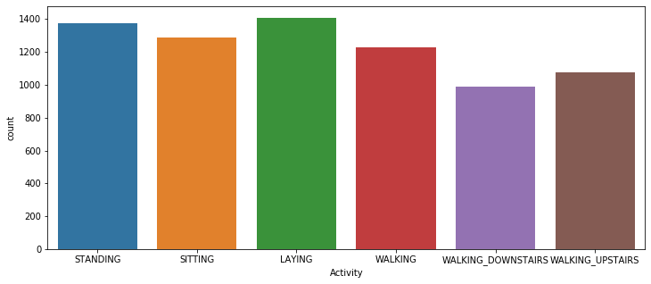

```python
plt.subplots(figsize=(12,5))
sns.countplot(train.Activity)
```

##### The above plot also lets us know that the major activities among all are LAYING and STANDING (which is natural with regard to humans), and the low frequent activities are WALKING-Up/Downstairs.

[figure not shown]

```python
plt.subplots(figsize=(7,7))
plt.pie(train.Activity.value_counts(),labels=train.Activity.unique(),autopct='%1.2f%%')
plt.show()
#we can see that all the features are equally distributed
```

### Splitting the data into INPUT and OUTPUT DataFrames:

x_train--> train INPUT; y_train --> train OUTPUT  
x_test--> test Input; y_test--> test INPUT

###### the subject column in all the data is not useful for our model so we're gonna 'drop' that column

```python
train.drop(['subject'],axis=1,inplace=True)
test.drop(['subject'],axis=1,inplace=True)
#train data:
x_train=train.drop(['Activity'],axis=1)
y_train=train.Activity
#test data:
x_test=test.drop(['Activity'],axis=1)
y_test=test.Activity
```

##### Now, before we start build our models, we consider the data from all the columns as input to our models as it can be observed from the FEATURE Engineering process that , there are numerous columns but on the ground level, all the columns are just an engineered product of the ACCELEROMETER and GYROSCOPE inputs recorded in a continuous 'time-series'.

##### There's more than one reason to include all the Features as input to this data, one of it being, the 'JERK' values, actions like the ones we're classifying in here, they all generate JERKS while the actions are being performed. Therfore, this value is important and cannot be ignored from being passed as an input inspite of being highly correlated to the other values.

##### So, here I'm trying to consider every column of the data to predict my classes.

### MODELING, TRAINING & TESTING:

### Logistic Regression:

```python
from sklearn.linear_model import LogisticRegression
lr=LogisticRegression()
lr.fit(x_train,y_train)
lr_train_predict=lr.predict(x_train)
lr_test_predict=lr.predict(x_test)
```

```python
##checking the metrics:
train_accu_score=np.zeros(5) ##to store the training accuracies of all the models
test_accu_score=np.zeros(5) ##to store the testing accuracies of all models
from sklearn.metrics import accuracy_score,confusion_matrix,classification_report
train_accu_score[0]=accuracy_score(y_train,lr_train_predict)
test_accu_score[0]=accuracy_score(y_test,lr_test_predict)
```

```python
print("Logistic Regression Train Accuracy: ",train_accu_score[0])
print("Logistic Regression Test Accuracy: ",test_accu_score[0])
```

```
Logistic Regression Train Accuracy:  0.9908868335146899
Logistic Regression Test Accuracy:  0.9586019681031558
```

```
Logistic Regression Train Confusion Matrix:
```

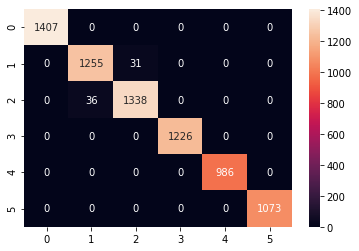

```python
print("Logistic Regression Train Confusion Matrix: ")
sns.heatmap(confusion_matrix(y_train,lr_train_predict),annot=True,fmt='1.0f')
```

```
Logistic Regression Test Confusion Matrix:
```

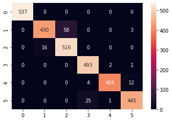

```python
print("Logistic Regression Test Confusion Matrix: ")
sns.heatmap(confusion_matrix(y_test,lr_test_predict),annot=True,fmt='1.0f')
```

```python
print("Logistic Regression Train Classification Report: ")
print(classification_report(y_train,lr_train_predict))
```

```
Logistic Regression Train Classification Report:
                    precision    recall  f1-score   support

            LAYING       1.00      1.00      1.00      1407
           SITTING       0.97      0.98      0.97      1286
          STANDING       0.98      0.97      0.98      1374
           WALKING       1.00      1.00      1.00      1226
WALKING_DOWNSTAIRS       1.00      1.00      1.00       986
  WALKING_UPSTAIRS       1.00      1.00      1.00      1073

          accuracy                           0.99      7352
         macro avg       0.99      0.99      0.99      7352
      weighted avg       0.99      0.99      0.99      7352
```

```python
print("Logistic Regression Test Classification Report: ")
print(classification_report(y_test,lr_test_predict))
```

```
Logistic Regression Test Classification Report:
                    precision    recall  f1-score   support

            LAYING       1.00      1.00      1.00       537
           SITTING       0.96      0.88      0.92       491
          STANDING       0.90      0.97      0.93       532
           WALKING       0.94      0.99      0.97       496
WALKING_DOWNSTAIRS       0.99      0.96      0.98       420
  WALKING_UPSTAIRS       0.97      0.94      0.95       471

          accuracy                           0.96      2947
         macro avg       0.96      0.96      0.96      2947
      weighted avg       0.96      0.96      0.96      2947
```

### K-Nearest Neighbors Classifier:

```python
from sklearn.neighbors import KNeighborsClassifier
knc_init=KNeighborsClassifier(n_neighbors=20,metric='euclidean')
knc_init.fit(x_train,y_train)
knc_init_train_predict=knc_init.predict(x_train)
knc_init_test_predict=knc_init.predict(x_test)
```

```python
#checking the metrics
print("train: ",accuracy_score(y_train,knc_init_train_predict))
print("test: ",accuracy_score(y_test,knc_init_test_predict))
```

```
train:  0.9665397170837867
test:  0.9056667797760435
```

##### Calculating the optimal value for n_neighbors using ELBOW method:

```python
score=[]
for k in range(1,20):
    knn_model=KNeighborsClassifier(n_neighbors=k)
    knn_model.fit(x_train,y_train)
    pred_test=knn_model.predict(x_test)
    score.append(accuracy_score(y_test,pred_test))
print(score)
```

[output not shown]

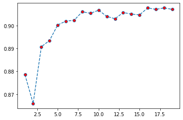

```python
#plotting the score
plt.plot(range(1,20),score,marker='o',markerfacecolor='r',linestyle='--')
```

Here it can be observed that the highest accuracy is achieved through the K-Nearest Neighbors Algorithm at the value where **n_neighbors=18**

```python
#So, let's build a model with the same parameter value
knc=KNeighborsClassifier(n_neighbors=18,metric='euclidean')
knc.fit(x_train,y_train)
knc_train_predict=knc.predict(x_train)
knc_test_predict=knc.predict(x_test)
#checking the metrics
train_accu_score[1]=accuracy_score(y_train,knc_train_predict)
test_accu_score[1]=accuracy_score(y_test,knc_test_predict)
print("KNN Classifier Train Accuracy: ",train_accu_score[1])
print("KNN Classifier Test Accuracy: ",test_accu_score[1])
```

```
KNN Classifier Train Accuracy:  0.9681719260065288
KNN Classifier Test Accuracy:  0.9077027485578555
```

```
K-Nearest Neighbors Train Confusion Matrix:
```

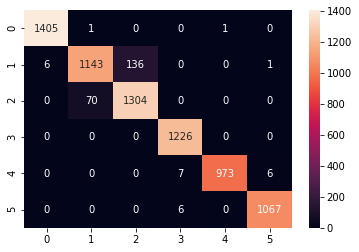

```python
print("K-Nearest Neighbors Train Confusion Matrix: ")
sns.heatmap(confusion_matrix(y_train,knc_train_predict),annot=True,fmt='1.0f')
```

```
K-Nearest Neighbors Test Confusion Matrix:
```

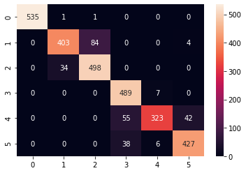

```python
print("K-Nearest Neighbors Test Confusion Matrix: ")
sns.heatmap(confusion_matrix(y_test,knc_test_predict),annot=True,fmt='1.0f')
```

```python
print("K-Nearest Neighbors Train Classification Report: ")
print(classification_report(y_train,knc_train_predict))
```

```
K-Nearest Neighbors Train Classification Report:
                    precision    recall  f1-score   support

            LAYING       1.00      1.00      1.00      1407
           SITTING       0.94      0.89      0.91      1286
          STANDING       0.91      0.95      0.93      1374
           WALKING       0.99      1.00      0.99      1226
WALKING_DOWNSTAIRS       1.00      0.99      0.99       986
  WALKING_UPSTAIRS       0.99      0.99      0.99      1073

          accuracy                           0.97      7352
         macro avg       0.97      0.97      0.97      7352
      weighted avg       0.97      0.97      0.97      7352
```

```python
print("K-Nearest Neighbors Test Classification Report: ")
print(classification_report(y_test,knc_test_predict))
```

```
K-Nearest Neighbors Test Classification Report:
                    precision    recall  f1-score   support

            LAYING       1.00      1.00      1.00       537
           SITTING       0.92      0.82      0.87       491
          STANDING       0.85      0.94      0.89       532
           WALKING       0.84      0.99      0.91       496
WALKING_DOWNSTAIRS       0.96      0.77      0.85       420
  WALKING_UPSTAIRS       0.90      0.91      0.90       471

          accuracy                           0.91      2947
         macro avg       0.91      0.90      0.90      2947
      weighted avg       0.91      0.91      0.91      2947
```

### Naive Bayes:

```python
from sklearn.naive_bayes import GaussianNB
nb=GaussianNB()
nb.fit(x_train,y_train)
nb_train_predict=nb.predict(x_train)
nb_test_predict=nb.predict(x_test)
#checking the metrics
train_accu_score[2]=accuracy_score(y_train,nb_train_predict)
test_accu_score[2]=accuracy_score(y_test,nb_test_predict)
print("Naive Bayes Classifier Train Accuracy: ",train_accu_score[2])
print("Naive Bayes Test Accuracy: ",test_accu_score[2])
```

```
Naive Bayes Classifier Train Accuracy:  0.7463275299238302
Naive Bayes Test Accuracy:  0.7702748557855447
```

```
Naive Bayes Train Confusion Matrix:
```

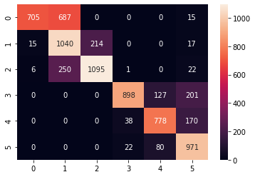

```python
print("Naive Bayes Train Confusion Matrix: ")
sns.heatmap(confusion_matrix(y_train,nb_train_predict),annot=True,fmt='1.0f')
```

```
Naive Bayes Test Confusion Matrix:
```

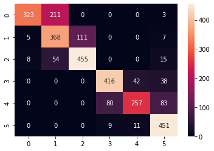

```python
print("Naive Bayes Test Confusion Matrix: ")
sns.heatmap(confusion_matrix(y_test,nb_test_predict),annot=True,fmt='1.0f')
```

```python
print("Naive Bayes Train Classification Report: ")
print(classification_report(y_train,nb_train_predict))
```

```
Naive Bayes Train Classification Report:
                    precision    recall  f1-score   support

            LAYING       0.97      0.50      0.66      1407
           SITTING       0.53      0.81      0.64      1286
          STANDING       0.84      0.80      0.82      1374
           WALKING       0.94      0.73      0.82      1226
WALKING_DOWNSTAIRS       0.79      0.79      0.79       986
  WALKING_UPSTAIRS       0.70      0.90      0.79      1073

          accuracy                           0.75      7352
         macro avg       0.79      0.76      0.75      7352
      weighted avg       0.80      0.75      0.75      7352
```

```python
print("Naive Bayes Test Classification Report: ")
print(classification_report(y_test,nb_test_predict))
```

```
Naive Bayes Test Classification Report:
                    precision    recall  f1-score   support

            LAYING       0.96      0.60      0.74       537
           SITTING       0.58      0.75      0.65       491
          STANDING       0.80      0.86      0.83       532
           WALKING       0.82      0.84      0.83       496
WALKING_DOWNSTAIRS       0.83      0.61      0.70       420
  WALKING_UPSTAIRS       0.76      0.96      0.84       471

          accuracy                           0.77      2947
         macro avg       0.79      0.77      0.77      2947
      weighted avg       0.79      0.77      0.77      2947
```

### Decision Tree:

```python
from sklearn.tree import DecisionTreeClassifier
dtree_init=DecisionTreeClassifier(criterion='entropy')
dtree_init.fit(x_train,y_train)
dtree_init_train_predict=dtree_init.predict(x_train)
dtree_init_test_predict=dtree_init.predict(x_test)
#checking the metrics
print("Decision Tree Classifier initial Train Accuracy: ",accuracy_score(y_train,dtree_init_train_predict))
print("Decision Tree Classifier initial Test Accuracy: ",accuracy_score(y_test,dtree_init_test_predict))
```

```
Decision Tree Classifier initial Train Accuracy:  1.0
Decision Tree Classifier initial Test Accuracy:  0.8527315914489311
```

##### This is a case of OVERFITTING

#### Hyper-parameter Tuning Using GridSearchCV:

```python
from sklearn.tree import DecisionTreeClassifier
dtree_hype=DecisionTreeClassifier(random_state=1)
grid_param={'criterion':['gini','entropy'],'min_samples_leaf':range(1,10,1)}
from sklearn.model_selection import GridSearchCV
grid_search=GridSearchCV(estimator=dtree_hype,param_grid=grid_param)
#applying the grid search:
grid_search.fit(x_train,y_train)
grid_search.best_params_
```

```
{'criterion': 'entropy', 'min_samples_leaf': 6}
```

```python
#Creating a final model
dtree=DecisionTreeClassifier(random_state=1,criterion='entropy',min_samples_leaf=6)
dtree.fit(x_train,y_train)
dtree_train_predict=dtree.predict(x_train)
dtree_test_predict=dtree.predict(x_test)
#checking the metrics
train_accu_score[3]=accuracy_score(y_train,dtree_train_predict)
test_accu_score[3]=accuracy_score(y_test,dtree_test_predict)
print("Decision Tree Classifier Train Accuracy: ",train_accu_score[3])
print("Decision Tree Classifier Test Accuracy: ",test_accu_score[3])
```

```
Decision Tree Classifier Train Accuracy:  0.985310119695321
Decision Tree Classifier Test Accuracy:  0.843909060061079
```

#### The model is still Over-Fitting

### Random Forest Classifier:

```python
from sklearn.ensemble import RandomForestClassifier
rfc=RandomForestClassifier(criterion='entropy')
rfc.fit(x_train,y_train)
rfc_train_predict=rfc.predict(x_train)
rfc_test_predict=rfc.predict(x_test)
#checking the metrics
train_accu_score[4]=accuracy_score(y_train,rfc_train_predict)
test_accu_score[4]=accuracy_score(y_test,rfc_test_predict)
print("Random Forest Classifier Train Accuracy: ",train_accu_score[4])
print("Random Forest Classifier Test Accuracy: ",test_accu_score[4])
```

```
Random Forest Classifier Train Accuracy:  1.0
Random Forest Classifier Test Accuracy:  0.9287410926365796
```

```
Random Forest Classifier Train Confusion Matrix:
```

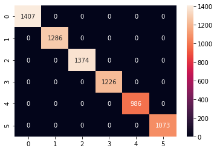

```python
print("Random Forest Classifier Train Confusion Matrix: ")
sns.heatmap(confusion_matrix(y_train,rfc_train_predict),annot=True,fmt='1.0f')
```

```
Random Forest Classifier Test Confusion Matrix:
```

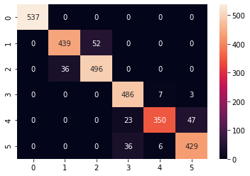

```python
print("Random Forest Classifier Test Confusion Matrix: ")
sns.heatmap(confusion_matrix(y_test,rfc_test_predict),annot=True,fmt='1.0f')
```

```python
print("Random Forest Classifier Train Classification Report: ")
print(classification_report(y_train,rfc_train_predict))
```

```
Random Forest Classifier Train Classification Report:
                    precision    recall  f1-score   support

            LAYING       1.00      1.00      1.00      1407
           SITTING       1.00      1.00      1.00      1286
          STANDING       1.00      1.00      1.00      1374
           WALKING       1.00      1.00      1.00      1226
WALKING_DOWNSTAIRS       1.00      1.00      1.00       986
  WALKING_UPSTAIRS       1.00      1.00      1.00      1073

          accuracy                           1.00      7352
         macro avg       1.00      1.00      1.00      7352
      weighted avg       1.00      1.00      1.00      7352
```

```python
print("Random Forest Classifier Test Classification Report: ")
print(classification_report(y_test,rfc_test_predict))
```

```
Random Forest Classifier Test Classification Report:
                    precision    recall  f1-score   support

            LAYING       1.00      1.00      1.00       537
           SITTING       0.92      0.89      0.91       491
          STANDING       0.91      0.93      0.92       532
           WALKING       0.89      0.98      0.93       496
WALKING_DOWNSTAIRS       0.96      0.83      0.89       420
  WALKING_UPSTAIRS       0.90      0.91      0.90       471

          accuracy                           0.93      2947
         macro avg       0.93      0.93      0.93      2947
      weighted avg       0.93      0.93      0.93      2947
```

## Visualizing the Accuracies obtained from each model:

```python
train_accu_score
```

```
array([0.99088683, 0.96817193, 0.74632753, 0.98531012, 1.        ])
```

```python
test_accu_score
```

```
array([0.95860197, 0.90770275, 0.77027486, 0.84390906, 0.92874109])
```

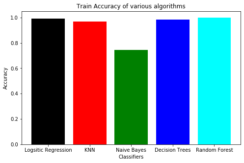

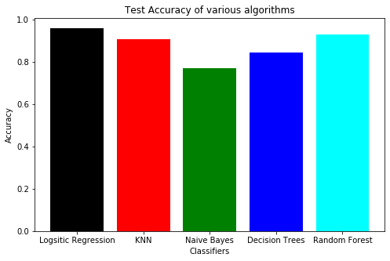

```python
plt.subplots(figsize=(8,5))
labels = ['Logsitic Regression', 'KNN','Naive Bayes','Decision Trees','Random Forest']
plt.bar(labels,train_accu_score,color=['black', 'red', 'green', 'blue', 'cyan'])
plt.xlabel('Classifiers')
plt.ylabel('Accuracy')
plt.title('Train Accuracy of various algorithms')


plt.subplots(figsize=(8,5))
labels = ['Logsitic Regression', 'KNN','Naive Bayes','Decision Trees','Random Forest']
plt.bar(labels,test_accu_score,color=['black', 'red', 'green', 'blue', 'cyan'])
plt.xlabel('Classifiers')
plt.ylabel('Accuracy')
plt.title('Test Accuracy of various algorithms')
```